# Data Wrangling and Classes

Week 2

Published

September 26, 2025

# Before we start

- Any questions?

[Download script](https://artur-baranov.github.io/nu-ps403-ds/scripts/ps403-d_02.qmd)

# Review of the Previous Session

Let’s refresh what we did last week.

**Review**

First of all, let’s load the `tidyverse` and `readxl` libraries. Then, load the Comparative Political Dataset from the last class.

```r
library(tidyverse)
library(readxl)

cpds = read_excel("data/cpds.xlsx")
```

Imagine you are interested in fractionalizon of electoral systems (you can read more about fractionalization after class [here](https://sk.sagepub.com/ency/edvol/the-encyclopedia-of-political-science/chpt/fractionalization-index)). Subset the following variables from the dataset: `year`, `country`, `rae_ele` and `fed`.

```r
cpds_subset = cpds ...
  ...(year, ...)
```

Rename the `rae_ele` to `fractionalization` in the `cpds_subset` dataframe.

```r
... = cpds_subset %>%
  ...(fractionalization = ...)
```

Draw a histogram to show the distribution of Douglas Rae’s index of electoral `fractionalization`.

```r
... +
  geom_histogram(...)
```

What is the minimum value? What is the maximum value?

```r
...
```

The index indicates that 1 corresponds to a fragmented system (votes are widely dispersed across parties), while 0 means that everyone voted for the same party. What is the average?

Draw a `geom_boxplot()` to see the relationship between the federalism (`fed`) on the x axis and `fractionalization` on the y axis. The federalism is coded as: 0 = no; 1 = weak; 2 = strong. Is something wrong?

```r
...
  ...(aes(...))
```

Don’t forget to remove the `cpds` and `cpds_subset` dataframes.

```r
rm(cpds, cpds_subset)
```

# Agenda for Today

- Data Classes
- Data Wrangling
- Presenting data with `tinytable`

# Exploring and Wrangling Data

Let’s load the data

```r
load(url("https://github.com/vdeminstitute/vdemdata/raw/6bee8e170578fe8ccdc1414ae239c5e870996bc0/data/vdem.RData"))
```

This is the V-Dem dataset. For your reference, their codebook is available [here](https://v-dem.net/documents/38/V-Dem_Codebook_v14.pdf).

The dataset is huge! Be careful

```r
nrow(vdem)
ncol(vdem)
```

```
[1] 27734
[1] 4607
```

Imagine you are interested in the relationship between regime type and physical violence. Let’s `select()` and rename the variables we will work with. Quite unfortunately, the names of the variables are not as straightforward. The regime index is `e_v2x_polyarchy_5C` and Physical violence index is `v2x_clphy`. And you can combine both actions in the same function!

```r
violence_data = vdem %>%
  select(country_name,
         year,
         regime = e_v2x_polyarchy_5C,
         violence = v2x_clphy)
```

Let’s see the result

```r
head(violence_data)
```

```
  country_name year regime violence
1       Mexico 1789      0    0.322
2       Mexico 1790      0    0.322
3       Mexico 1791      0    0.322
4       Mexico 1792      0    0.322
5       Mexico 1793      0    0.322
6       Mexico 1794      0    0.322
```

That was the first step. Let’s subset even more data. Let’s analyze the distribution of the Violence Index in the year 2000. We need to **filter** the data for this task.

```r
violence_2000 = violence_data %>%
  filter(year == 2000)
```

The higher the number, the better the physical integrity in a given country.

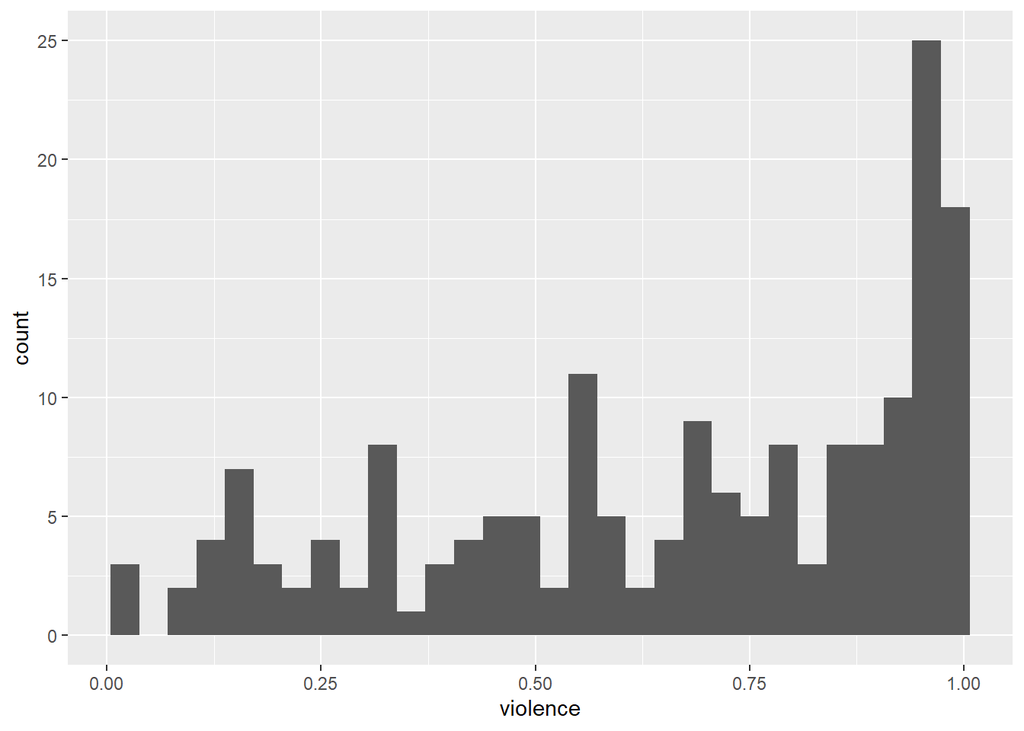

```r
ggplot(data = violence_2000) +
  geom_histogram(aes(x = violence))
```

Let’s customize the plot a bit.

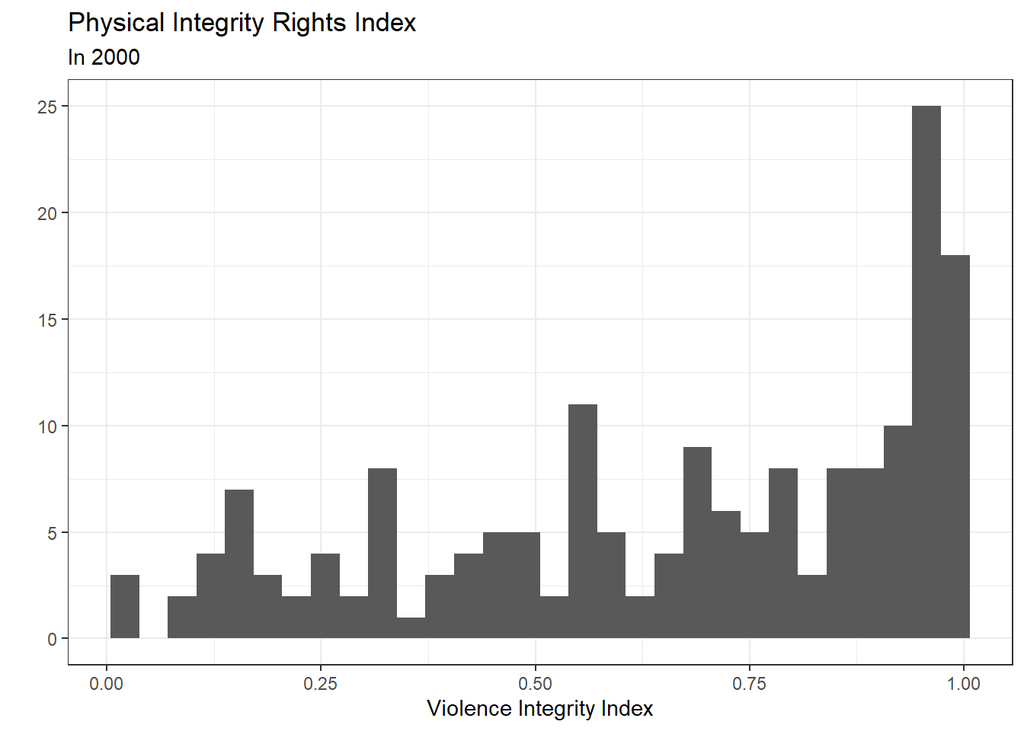

```r
ggplot(data = violence_2000) +
  geom_histogram(aes(x = violence)) +
  labs(title = "Physical Integrity Rights Index",
       subtitle = "In 2000",
       x = "Violence Integrity Index",
       y = "") +
  theme_bw()
```

Imagine, you asked the following question. Is it true that in the year 2000 democracies had better violence integrity rights index?

Firstly, you we need to differentiate between the regimes. Using `mutate()` function we can create and modify existing variables. Let’s do that!

```r
violence_2000 = violence_2000 %>%
  mutate(democracy = case_when(regime >= 0.5 ~ "Democracy",
                               regime < 0.5 ~ "Autocracy"))

head(violence_2000)
```

```
  country_name year regime violence democracy
1       Mexico 2000   0.75    0.573 Democracy
2     Suriname 2000   0.75    0.871 Democracy
3       Sweden 2000   1.00    0.990 Democracy
4  Switzerland 2000   1.00    0.974 Democracy
5        Ghana 2000   0.75    0.946 Democracy
6 South Africa 2000   0.75    0.834 Democracy
```

There are multiple ways to visually compare between two groups.

Let’s draw histograms first.

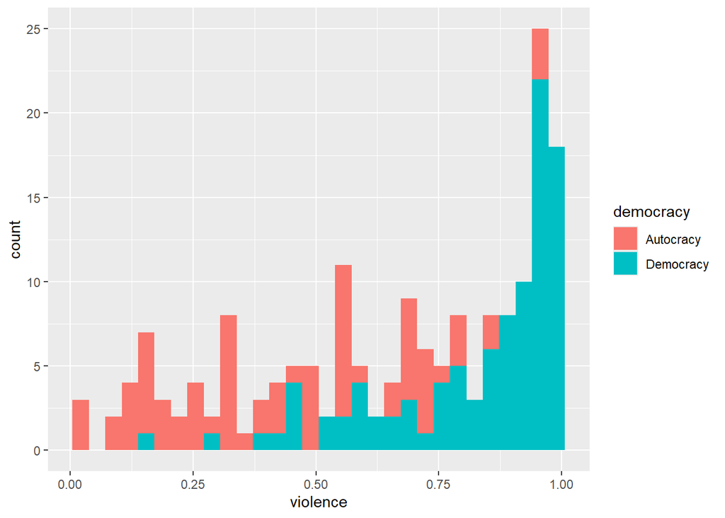

```r
ggplot(violence_2000) +
  geom_histogram(aes(x = violence, fill = democracy))
```

But comparing distributions between groups is easier with the boxplot. Are they different?

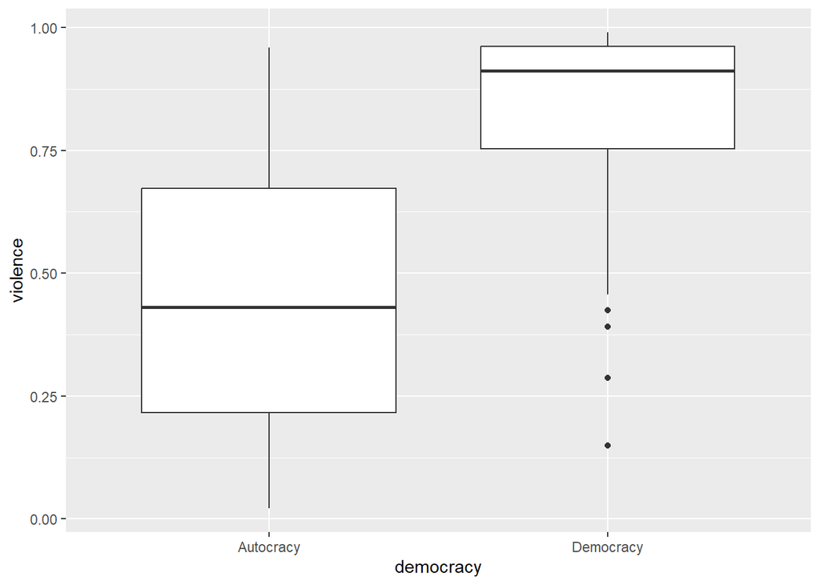

```r
ggplot(violence_2000) +
  geom_boxplot(aes(x = democracy, y = violence))
```

# Data Classes

```r
with(violence_2000,
     table(regime))
```

```
regime
   0 0.25  0.5 0.75    1
  32   45   33   30   37
```

```r
table(violence_2000$democracy)
```

```
Autocracy Democracy
       77       100
```

Theoretically, we can plot even more detailed graph using `geom_boxplot()` if we use `regime` data. Let’s see. Something fails!

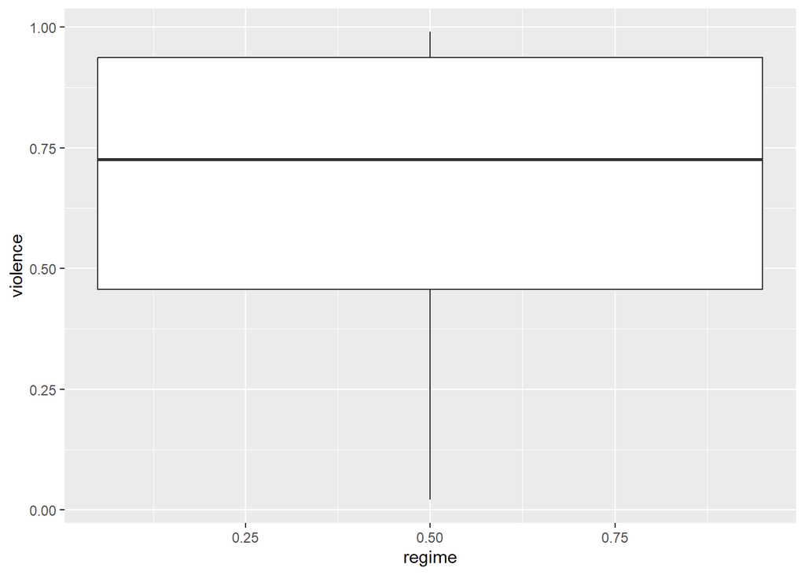

```r
ggplot(violence_2000) +
  geom_boxplot(aes(x = regime, y = violence))
```

Let’s correct. Now it’s better!

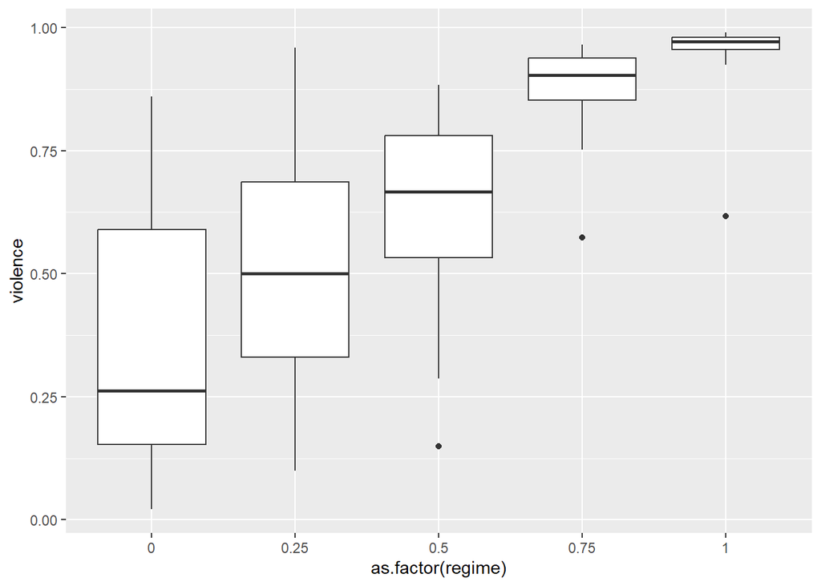

```r
ggplot(violence_2000) +
  geom_boxplot(aes(x = as.factor(regime), y = violence))
```

The problem is, by default R treats `regime` variable as continuous, but it’s categorical! Explore the graph below.

```r
library(DiagrammeR)
mermaid("
graph LR
    D[Data] --> C[Categorical]
    D --> N[Numerical]
    C --> no[Nominal]
    C --> Or[Ordinal]
    N --> di[Discrete]
    N --> co[Continuous]
    no --> c[Character]
    Or --> f[Factor]
    di --> i[Integer]
    co --> n[Numeric]
")
```

[interactive chart not shown]

These are the basic classes of data in R. Some examples might include:

- **Nominal**: Names, Labels, Brands, Country names, etc.
- **Ordinal**: Educational Levels (High School-BA-MA-PhD), Customer Rating (Unsatisfied-Neutral-Satisfied), etc.
- **Discrete**: Number of customers per day, number of seats won by political parties, etc.
- **Continuous**: Height of people, voter turnout, etc.

You can check the class using `class()` function.

```r
class(violence_2000$regime)
```

```
[1] "numeric"
```

And you can make it categorical by transforming it to factor using `as.factor()`. Other functions are `as.numeric()`and `as.character()`.

```r
violence_2000$regime = as.factor(violence_2000$regime)
```

# Summarizing and Presenting data

Treating a variable as categorcal would help us to summarize data per category. For example, you want to present information of average level of violence in different regimes.

Let’s switch to the main dataset. Quickly prepare the data using `case_when()` function – a better version of `ifelse()`. Here we are using the codebook’s guidence to rename the categories.

```r
violence_data = violence_data %>%
  mutate(regime = case_when(regime > 0.75 ~ "Democratic",
                            regime == 0.75 ~ "Minimally Democratic",
                            regime == 0.5 ~ "Ambivalent",
                            regime == 0.25 ~ "Autocratic",
                            regime < 0.25 ~ "Closed Autocratic"))

head(violence_data)
```

```
  country_name year            regime violence
1       Mexico 1789 Closed Autocratic    0.322
2       Mexico 1790 Closed Autocratic    0.322
3       Mexico 1791 Closed Autocratic    0.322
4       Mexico 1792 Closed Autocratic    0.322
5       Mexico 1793 Closed Autocratic    0.322
6       Mexico 1794 Closed Autocratic    0.322
```

A tricky but helpful operation is groupping a variable, and then calculating statistics. [This picture really helps me wrap my head around it](https://artur-baranov.github.io/images/groupby_sum_eng.png).

```r
regime_violence = violence_data %>%
  group_by(regime) %>%
  summarize(average = mean(violence, na.rm = TRUE))

regime_violence
```

```
# A tibble: 6 × 2
  regime               average
  <chr>                  <dbl>
1 Ambivalent             0.733
2 Autocratic             0.584
3 Closed Autocratic      0.361
4 Democratic             0.955
5 Minimally Democratic   0.874
6 <NA>                   0.466
```

Finally, let’s present that in a nice way using `tinytable` library.

```r
library(tinytable)

regime_violence %>%
  tt(title = "Average level of violence in different regimes")
```

| regime | average |
| --- | --- |
| Ambivalent | 0.7333526 |
| Autocratic | 0.5838729 |
| Closed Autocratic | 0.3613431 |
| Democratic | 0.9548574 |
| Minimally Democratic | 0.8740276 |
| NA | 0.4657441 |

# Check list

- I am confident in drawing distributions: either using `geom_histogram()` or `geom_boxplot()`
- I know what data classes are, and how to change them, too.
- I know how to recode variable using combination of `case_when()` and `mutate()`
- I can easily `summarize()` variables using `group_by()` to present statistics by category
- I can present nice tables with `tinytable` library

# Optional Exercises

Create a new `violence_2010` dataset, by subsetting `violence_data` for year 2010.

**Solution**

```r
violence_2010 = violence_data %>%
  ...
```

Using `mutate()` and `case_when()`, create a new variable `violence_binary` that is “High integrity” if the violence variable is greater or equal to 0.5, and “Low integrity” if it is less than 0.5.

**Solution**

```r
violence_2010 = violence_2010 %>%
  ...(violence_binary = case_when(... >= 0.5 ~ "High Integrity",
                                     ...))
```

Compare the two variables coding: `violence` and `violence_binary`. Check there classes. What is the difference? Briefly describe the type of each variable. Imagine you were to draw a boxplot, how would class differences in the variables define their use case on the graph?

**Solution**

YOUR SOLUTION HERE

```r
...
```

Let’s calculate the average regime type per `violence_binary`. Use `group_by()` and `summarize()`. Save it to `output` object.

**Solution**

```r
output = violence_2010 %>%
  ...
```

Using `tt()` present the `output`.

**Solution**

```r
...
```